# Week 6: Wrangle Data II

# Chapter 12: Tidy data

```r
library("tidyverse")
```

## 12.2 Tidy data

1. Each variable must have its own column.
2. Each observation must have its own row.
3. Each value must have its own cell.

Basically: 1. Put each dataset in a tibble. 2. Put each variable in a column

consistency makes life easier vectorized data works best with R’s vector functions ### 12.2.1 Exercises 2. Compute the rate for table2, and table4a + table4b. You will need to perform four operations: Extract the number of TB cases per country per year. Extract the matching population per country per year. Divide cases by population, and multiply by 10000. Store back in the appropriate place. Which representation is easiest to work with? Which is hardest? Why?

```r
table2 <- tribble(
~ country, ~ year, ~type, ~ count,
'Afghanistan', 1999, 'cases', 745,
'Afghanistan', 1999, 'population', 19987071,
'Afghanistan', 2000, 'cases', 2666,
'Afghanistan', 2000, 'population', 20595360,
'Brazil', 1999, 'cases', 37737,
'Brazil', 1999, 'population', 172006362
)

table2_pop <- filter(table2, type == "population")

table2_cases <- filter(table2, type == "cases")


(table2_neat <- left_join(table2_pop, table2_cases, c("country", "year")))
```

| country | year | type.x | count.x | type.y | count.y |
| --- | --- | --- | --- | --- | --- |
| Afghanistan | 1999 | population | 19987071 | cases | 745 |
| Afghanistan | 2000 | population | 20595360 | cases | 2666 |
| Brazil | 1999 | population | 172006362 | cases | 37737 |

```r
(table2_neat %>%
  mutate(
    rate = (count.y / count.x) * 10000
  )
)
```

| country | year | type.x | count.x | type.y | count.y | rate |
| --- | --- | --- | --- | --- | --- | --- |
| Afghanistan | 1999 | population | 19987071 | cases | 745 | 0.372741 |
| Afghanistan | 2000 | population | 20595360 | cases | 2666 | 1.294466 |
| Brazil | 1999 | population | 172006362 | cases | 37737 | 2.193930 |

```r
table4a <- tribble(
~country, ~`1999`, ~`2000`,
'Afghanistan', 745, 2666,
'Brazil', 37737, 80488,
'China', 212258, 213766)

table4b  <- tribble(
~country, ~`1999`, ~`2000`,
'Afghanistan' , 19987071, 20595360,
'Brazil', 172006362, 174504898,
'China', 1272915272, 1280428583)

table4a_1999 <- select(table4a, -`2000`, cases = `1999`)
table4a_2000 <- select(table4a, -`1999`, cases = `2000`)
table4b_1999 <- select(table4b, -`2000`, population = `1999`)
table4b_2000 <- select(table4b, -`1999`, population = `2000`)

table4a2 <- left_join(table4a_1999, table4a_2000)
(table4a2 <- mutate(table4a2, year = "1999"))
```

| country | cases | year |
| --- | --- | --- |
| Afghanistan | 745 | 1999 |
| Brazil | 37737 | 1999 |
| China | 212258 | 1999 |

```r
NA
```

## 12.3 Spreading and gathering

### 12.3.1 Gathering

sometimes the column names are not the names of the variables but the values of the variable

gather(DATAFRAME, the columns that represent variable values, key = “year” (the variable in the column names, value = “case” (the variable in the current columns)))

use select() notation

### 12.3.2 Spreading

sometimes two variables are smooshed into one column and one observation is spread across multiple rows

spread(key = column with varaible names, value = column that contains values from multiple variables)

### 12.3.3 Exercises

1. Why are gather() and spread() not perfectly symmetrical? Spreading and regathering the data converts year from a double to a factor. Column names can only be numbers if they are surrounded by backtick notation, and that clearly does not translate into gather() understanding that those backtick’d names are doubles. I think the convert argument fixes this?

```r
(stocks <- tibble(
  year   = c(2015, 2015, 2016, 2016),
  half  = c(   1,    2,     1,    2),
  return = c(1.88, 0.59, 0.92, 0.17)
))
```

| year | half | return |
| --- | --- | --- |
| 2015 | 1 | 1.88 |
| 2015 | 2 | 0.59 |
| 2016 | 1 | 0.92 |
| 2016 | 2 | 0.17 |

```r
(stocks %>%
  spread(year, return) %>%
  gather("year", "return", `2015`:`2016`, convert = TRUE))
```

| half | year | return |
| --- | --- | --- |
| 1 | 2015 | 1.88 |
| 2 | 2015 | 0.59 |
| 1 | 2016 | 0.92 |
| 2 | 2016 | 0.17 |

2. Why does this code fail? No backtick notation.

```
table4a %>%
  gather(1999, 2000, key = "year", value = "cases")
```

3. Why does spreading the given tibble fail? How could you add a new column to fix the problem?

Phillip Woods has two different values marked as “age” in the key column. Maybe add a year_measured column?

4. Tidy the simple tibble below. Do you need to spread or gather it? What are the variables? The column names male and female are actually variables, so they need to be gathered with their values turned into a count column. I think the pregnant column is okay.

```r
preg <- tribble(
  ~pregnant, ~male, ~female,
  "yes",     NA,    10,
  "no",      20,    12
)
preg %>%
  gather(male, female, key = "gender", value = "count")
```

| pregnant | gender | count |
| --- | --- | --- |
| yes | male | NA |
| no | male | 20 |
| yes | female | 10 |
| no | female | 12 |

## 12.4 Separating and uniting

what do you do when one column cotains two variables?  
### 12.4.1 Separate separate() pulls column apart into multiple columns, splitting wherever a separator character appears separate(COLUMN TO SPLIT, into = c(“column of first variable”, "column of second variable)) by default spits on non-alphanumeric; can specify with sep argument  
also by default – leaves column as its original type; set convert = TRUE to try to fix it

ALSO: if you pass a vector of integers to sep, it will interpret as positions to split at  
1 = far left of string  
-1 = far right of string

### 12.4.2 Unite

combine multiple columns into single column unite(NEW COLUMN, column to join, column to join) default places an underscore between the values from different columns that are linked  
no separator, sep = ""

### 12.4.3 Exercises

1. What do the extra and fill arguments do in separate()? Experiment with the various options for the following two toy datasets. When you are pulling a column apart into X number of pieces, sometimes the data in the cell is not going to fit that pattern. extra (default = warn) deals with how to deal with X + n values in a cell; fill deals with how to deal with X - n. fill defaults to filling from the right with NA

```r
tibble(x = c("a,b,c", "d,e,f,g", "h,i,j")) %>%
  separate(x, c("one", "two", "three"))
```

```
Expected 3 pieces. Additional pieces discarded in 1 rows [2].
```

| one | two | three |
| --- | --- | --- |
| a | b | c |
| d | e | f |
| h | i | j |

```r
tibble(x = c("a,b,c", "d,e", "f,g,i")) %>%
  separate(x, c("one", "two", "three"))
```

```
Expected 3 pieces. Missing pieces filled with `NA` in 1 rows [2].
```

| one | two | three |
| --- | --- | --- |
| a | b | c |
| d | e | NA |
| f | g | i |

2. Both unite() and separate() have a remove argument. What does it do? Why would you set it to FALSE?  
   The remove argument takes the original input columns that you are sticking together or taking apart and removes it from the modified dataframe. If you are not sure that you have gotten the conditions for separation or union correct or if there is still relevant information in the linked or split data, setting remove = FALSE will keep that information.
3. Compare and contrast separate() and extract(). Why are there three variations of separation (by position, by separator, and with groups), but only one unite?

**I’m not sure what extract() function this question is asking about.**

## 12.5 Missing values

A missing value can be explicitly flagged (i.e. with NA) or implicit (just completely missing) na.rm = TRUE in gather() turns explicit missing into implicit complete() – takes a set of columns and finds all unique combinations, then ensures original data set has all those values

If empty cells mean that the row above is supposed to be carried down, you can use fill()  
fill() takes a set of columns where you want missing values to be replaced by the most recent non-missing value

## 12.6 Case Study

```
View(who)
```

```r
who1 <- who %>%
  gather(new_sp_m014:newrel_f65, key = "key", value = "cases", na.rm = TRUE)
who1 %>%
  count(key)
```

| key | n |
| --- | --- |
| new_ep_f014 | 1032 |
| new_ep_f1524 | 1021 |
| new_ep_f2534 | 1021 |
| new_ep_f3544 | 1021 |
| new_ep_f4554 | 1017 |
| new_ep_f5564 | 1017 |
| new_ep_f65 | 1014 |
| new_ep_m014 | 1038 |
| new_ep_m1524 | 1026 |
| new_ep_m2534 | 1020 |

[output cut: 46 more lines]

```r
who2 <- who1 %>%
  mutate(key = stringr::str_replace(key, "newrel", "new_rel"))
who2
```

| country | iso2 | iso3 | year | key | cases |
| --- | --- | --- | --- | --- | --- |
| Afghanistan | AF | AFG | 1997 | new_sp_m014 | 0 |
| Afghanistan | AF | AFG | 1998 | new_sp_m014 | 30 |
| Afghanistan | AF | AFG | 1999 | new_sp_m014 | 8 |
| Afghanistan | AF | AFG | 2000 | new_sp_m014 | 52 |
| Afghanistan | AF | AFG | 2001 | new_sp_m014 | 129 |
| Afghanistan | AF | AFG | 2002 | new_sp_m014 | 90 |
| Afghanistan | AF | AFG | 2003 | new_sp_m014 | 127 |
| Afghanistan | AF | AFG | 2004 | new_sp_m014 | 139 |
| Afghanistan | AF | AFG | 2005 | new_sp_m014 | 151 |
| Afghanistan | AF | AFG | 2006 | new_sp_m014 | 193 |

[output cut: 990 more lines]

```r
who3 <- who2 %>%
  separate(key, c("new", "type", "sexage", sep = "_"))
```

```
Expected 4 pieces. Missing pieces filled with `NA` in 76046 rows [1, 2, 3, 4, 5, 6, 7, 8, 9, 10, 11, 12, 13, 14, 15, 16, 17, 18, 19, 20, ...].
```

```r
who3 %>%
  count(new)
```

| new | n |
| --- | --- |
| new | 76046 |

```r
who4 <- who3 %>%
  select(-new, -iso2, -iso3)

who5 <- who4 %>%
  separate(sexage, c("sex", "age"), sep = 1)
who5
```

| country | year | type | sex | age | _ | cases |
| --- | --- | --- | --- | --- | --- | --- |
| Afghanistan | 1997 | sp | m | 014 | NA | 0 |
| Afghanistan | 1998 | sp | m | 014 | NA | 30 |
| Afghanistan | 1999 | sp | m | 014 | NA | 8 |
| Afghanistan | 2000 | sp | m | 014 | NA | 52 |
| Afghanistan | 2001 | sp | m | 014 | NA | 129 |
| Afghanistan | 2002 | sp | m | 014 | NA | 90 |
| Afghanistan | 2003 | sp | m | 014 | NA | 127 |
| Afghanistan | 2004 | sp | m | 014 | NA | 139 |
| Afghanistan | 2005 | sp | m | 014 | NA | 151 |
| Afghanistan | 2006 | sp | m | 014 | NA | 193 |

[output cut: 990 more lines]

More complex/many pipe version

```r
whofin <- who %>%
  gather(key, value, new_sp_m014:newrel_f65, na.rm = TRUE)  %>%
  mutate(key = stringr::str_replace(key, "newrel", "new_rel")) %>%
  separate(key, c("new", "var", "sexage")) %>%
  select(-new, -iso2, -iso3) %>%
  separate(sexage, c("sex", "age"), sep = 1)
```

### 12.6.1 Exercises

```r
who %>%
  count(iso3)
```

| iso3 | n |
| --- | --- |
| ABW | 34 |
| AFG | 34 |
| AGO | 34 |
| AIA | 34 |
| ALB | 34 |
| AND | 34 |
| ANT | 30 |
| ARE | 34 |
| ARG | 34 |
| ARM | 34 |

[output cut: 209 more lines]

4. For each country, year, and sex compute the total number of cases of TB. Make an informative visualisation of the data.

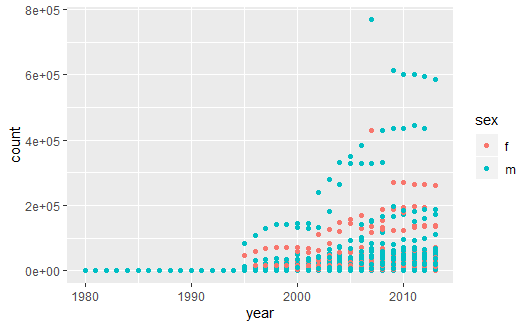

```r
whofin %>%
  group_by(country, year, sex) %>%
  summarise(
    count = sum(value)
  ) %>%
  ggplot(aes(x = year, y = count)) +
    geom_point(aes(color = sex))
```